# Introduction to Open Data Science: Rstudio Exercise2

Leena Huiku

18112018

# Exercise 2. Analysis of the Learning Data

# Description of data

The data of the analysis derives from the survey “Learning Approaches and Students’ Achievements” in an Introductory Statistics Course in Finland in 2014. The target of the study is to measure the relationship between the students’ learning approaches and their achievements.

There are 183 observations and 60 variables. Most of the questions are learning related questions, the answers are given on Likert scale from 1 to 5. Some background variables (age, attitude to statistics, points) are included as well. The learning approaches variables - deep learning, surface learning and strategic learning - are created by combing questions that can be thought to measure the same dimension. The combination variables are averaged.

# Load of data

```r
learning2014v2 <- as.data.frame(read.table('learning2014.csv', sep="\t", header=TRUE))
```

# Explore the structure of the dataframe

```r
str(learning2014v2)
```

```
## 'data.frame':    166 obs. of  7 variables:
##  $ gender  : Factor w/ 2 levels "F","M": 1 2 1 2 2 1 2 1 2 1 ...
##  $ age     : int  53 55 49 53 49 38 50 37 37 42 ...
##  $ attitude: int  37 31 25 35 37 38 35 29 38 21 ...
##  $ points  : int  25 12 24 10 22 21 21 31 24 26 ...
##  $ deep    : num  3.58 2.92 3.5 3.5 3.67 ...
##  $ stra    : num  3.38 2.75 3.62 3.12 3.62 ...
##  $ surf    : num  2.58 3.17 2.25 2.25 2.83 ...
```

# Explore the dimension of the dataframe

```r
dim(learning2014v2)
```

```
## [1] 166   7
```

# Show a graphical overview of the data and show summaries of the variables in the data.

If there are a handul of variables, it is possible to visulize The relationships between the variables in a single plot. A scatter plot matrix can be drawn by using function ggpairs and coloured by the gender variable.

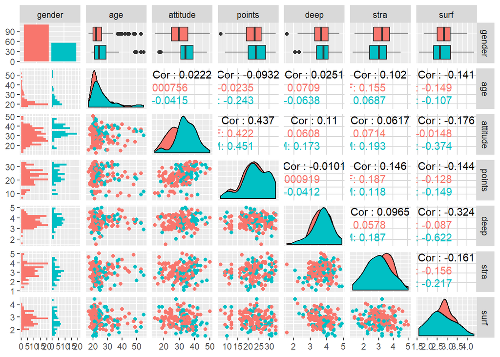

```r
p <- ggpairs(learning2014v2, mapping = aes(col=gender), lower = list(combo = wrap("facethist", bins = 20)))
p
```

# A summary of each of the variables

```r
summary(learning2014v2)
```

```
##  gender       age           attitude         points           deep
##  F:110   Min.   :17.00   Min.   :14.00   Min.   : 7.00   Min.   :1.583
##  M: 56   1st Qu.:21.00   1st Qu.:26.00   1st Qu.:19.00   1st Qu.:3.333
##          Median :22.00   Median :32.00   Median :23.00   Median :3.667
##          Mean   :25.51   Mean   :31.43   Mean   :22.72   Mean   :3.680
##          3rd Qu.:27.00   3rd Qu.:37.00   3rd Qu.:27.75   3rd Qu.:4.083
##          Max.   :55.00   Max.   :50.00   Max.   :33.00   Max.   :4.917
##       stra            surf
##  Min.   :1.250   Min.   :1.583
##  1st Qu.:2.625   1st Qu.:2.417
##  Median :3.188   Median :2.833
##  Mean   :3.121   Mean   :2.787
##  3rd Qu.:3.625   3rd Qu.:3.167
##  Max.   :5.000   Max.   :4.333
```

# Description and interpretation of the outputs

The graphical overview and the summary of the data showcase the large range of variables. The distribution of the variables is quite wide. The target of this analysis is to clarify the relationship of the student’s learning approaches and the results achieved. The correlations between variables are rather weak in all cases. The attitude variable is exception, it correlates strongly with the points variable. The age distribution shows that most students are at their twenties as could be assumed. The gender distribution is skewed, significantly more female students attended the course than male. The distributions of attitude, deep, stra and surf variables follow rather close to normal distribution. The points distribution is skewed, the distribution demonstrates that the student achieved good results.

# Regression model fitting

A linear regression model can be fit using lm function The explanatory variables are attitude, deep and stra.

```r
learning2014v2_model <- lm(points ~ attitude + deep + stra, data = learning2014v2)
```

```r
summary(learning2014v2_model)
```

```
##
## Call:
## lm(formula = points ~ attitude + deep + stra, data = learning2014v2)
##
## Residuals:
##      Min       1Q   Median       3Q      Max
## -17.5239  -3.4276   0.5474   3.8220  11.5112
##
## Coefficients:
##             Estimate Std. Error t value Pr(>|t|)
## (Intercept) 11.39145    3.40775   3.343  0.00103 **
## attitude     0.35254    0.05683   6.203 4.44e-09 ***
## deep        -0.74920    0.75066  -0.998  0.31974
## stra         0.96208    0.53668   1.793  0.07489 .
## ---
## Signif. codes:  0 '***' 0.001 '**' 0.01 '*' 0.05 '.' 0.1 ' ' 1
##
## Residual standard error: 5.289 on 162 degrees of freedom
## Multiple R-squared:  0.2097, Adjusted R-squared:  0.195
## F-statistic: 14.33 on 3 and 162 DF,  p-value: 2.521e-08
```

The dependent variable is points and the explanatory variables are attitude, deep and stra.

The model is found by minimizing the sum of squared residuals. First there is a five point summary of residuals of the model. The coefficients give the estimates of the parameters of the model. Intercept relates to parameters of output variable.

The estimation describes the effect of an explanatory variable on the output variable. P value of the statistical test is very low in case attitude so we can conclude that there is statistical relationship between attitude and points. The P test values of deep and stra are much higher and indicates that the variables don’t have strong relationship with output variable. The deep variable has lowest correlation with points, so it can be excluded from the further analysis.

The explanatory variables in the next fitted test are attitude and stra.

```r
learning2014v2_model <- lm(points ~ attitude + stra, data = learning2014v2)
```

```r
summary(learning2014v2_model)
```

```
##
## Call:
## lm(formula = points ~ attitude + stra, data = learning2014v2)
##
## Residuals:
##      Min       1Q   Median       3Q      Max
## -17.6436  -3.3113   0.5575   3.7928  10.9295
##
## Coefficients:
##             Estimate Std. Error t value Pr(>|t|)
## (Intercept)  8.97290    2.39591   3.745  0.00025 ***
## attitude     0.34658    0.05652   6.132 6.31e-09 ***
## stra         0.91365    0.53447   1.709  0.08927 .
## ---
## Signif. codes:  0 '***' 0.001 '**' 0.01 '*' 0.05 '.' 0.1 ' ' 1
##
## Residual standard error: 5.289 on 163 degrees of freedom
## Multiple R-squared:  0.2048, Adjusted R-squared:  0.1951
## F-statistic: 20.99 on 2 and 163 DF,  p-value: 7.734e-09
```

# Final analysis

## Diagnostic plots and assumptions and their validity of the model

There are three assumptions of linear regression models: the errors are normally distributed, they are not correlated and have constant variance. QQ-plot of the residuals provides a method to explore the assumption that the errors are normally distributed. The constant variance assumption implies that the size of the errors should not depend on the explanatory variables and it can be explored with a simple scatter plot of residuals versus model predictions. Any pattern in the scatter plot implies a problem with the assumptions.

The next diagnostic plots are produced: Residuals vs Fitted values, Normal QQ-plot, Residuals vs Leverage.

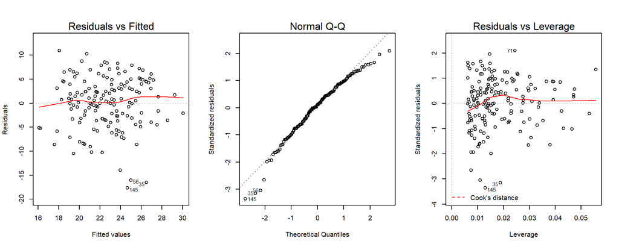

```r
par(mfrow = c(1,3))
# Draw diagnostic plots using the plot() function. Choose the plots 1, 2 and 5
plot(learning2014v2_model, which = c(1,2,5))
```

# Interpretation of the plots:

The Residuals vs Fitted plot doesn’t show any kind of pattern and the values are randomly distributed. Based on that, it can be concluded that the errors are not correlated with the explanatory variables and their size is not dependent on the explanatory variables.

The Normal Q-Q-plot Residuals diagnostic plot showcases that the model fits to the theoretical model rather well. The better the points are within the line, the better the model fits to the normality assumption.